# In vitroにおけるAde4粒子形成に対する各種プリンの作用

MT

2023-01-18

# 1 この事例で扱うデータと統計

**カテゴリ変数**：作用させたプリンヌクレオチド:`metabolite`（mock, SAMP, GMP, AMP, ADP, ATP）  
**数値変数**： 1視野内の粒子の輝度の総和:`sum_intden`, 1視野内の粒子の輝度の平均値:`mean_mean`  
**グラフ**：棒グラフ（平均） + エラーバー（1SD） + ドットプロット（各データポイント）  
**統計**：Shapiro-Wilk検定による正規性の検証、パラメトリックな1元配置分散分析、Tukey-Kramerの多重検定

# 2 データの取得と読み込み

In vitroのAde4-mNG粒子形成に対する各種プリンヌクレオチドの作用を観察。蛍光顕微鏡観察後、画像処理により粒子の蛍光強度を計測し、csvファイルで出力。

```r
library(pacman)
# パッケージをまとめてロード
p_load(tidyverse, openxlsx, readxl, ggtext, multcomp, ggsignif, knitr, nparcomp, rstatix, dunn.test)
```

読み込むcsvファイルが入っているフォルダを指定。ファイル名リストを取得。

```r
import_file_path <- "2023-01-18_ivc_metabolites_csv"
csv_list<- list.files(import_file_path, full.names = TRUE, recursive = TRUE, pattern = "*.csv")
```

`spply()`を使い、ファイル名リストから全てのファイルを一括で読み込み、データフレームのリストを作成。さらに`bind_rows()`でデータフレームを縦に連結して１つにする。

```r
mergedf <- csv_list %>%
  sapply(., read.csv, header =TRUE, sep = ",", stringsAsFactors = F, simplify = F) %>%
  bind_rows()
```

`mutate()`で新しい変数`metabolite`を作成。また顕微鏡観察開始時の確認のために撮影したテストデータを除く。

```r
mergedf <-
  mergedf %>%
  mutate(metabolite =case_when(
    str_detect(file, "mock") ~ "mock",
    str_detect(file, "samp") ~ "SAMP",
    str_detect(file, "amp") ~ "AMP",
    str_detect(file, "gmp") ~ "GMP",
    str_detect(file, "adp") ~ "ADP",
    str_detect(file, "atp") ~ "ATP")
  )
# test dataを除く
mergedf <- mergedf %>%
  filter(!is.na(metabolite))
```

この時点では変数`metabolite`は文字列型なのでfactor型に変換しておく。文字列型だと多重検定でエラーになる。さらにfct_relevelでレベル順を規定する。

```r
mergedf$metabolite <- as_factor(mergedf$metabolite)  ##
mergedf$metabolite <- fct_relevel(mergedf$metabolite, c("mock","SAMP", "GMP","AMP","ADP","ATP"))
levels(mergedf$metabolite)
```

```
## [1] "mock" "SAMP" "GMP"  "AMP"  "ADP"  "ATP"
```

# 3 データの集計

観察した粒子の輝度、総輝度数（輝度×面積）の平均とSDを求める。変数`metabolite`でグループ分け。また1ｘSDに相当するerror barを書くための範囲を設定。

```r
mean_sd_mean <-
  mergedf %>% group_by(metabolite) %>%
  summarise(
    mean_mean = mean(Mean),
    sd_mean = sd(Mean),
    N = n()
  )
## 1ｘSDに相当するerror barを書くための範囲を設定
limits_mean <- aes(ymax = mean_mean + sd_mean, ymin = mean_mean - sd_mean)

mean_sd_intden <-
  mergedf %>% group_by(metabolite) %>%
  summarise(
    mean_intden = mean(IntDen),
    sd_intden = sd(IntDen),
    N = n()
  )
limits_intden <- aes(ymax = mean_intden + sd_intden, ymin = mean_intden - sd_intden)
```

粒子の総輝度を1視野（1ファイル）毎に合計した値`sum_intden`を求め、同様に平均とSDを算出。

```r
sum_intden <-
  mergedf %>% group_by(metabolite, file) %>%
  summarise(
    sum_intden = sum(IntDen), N_particle=n())

mean_sd_sum_intden <-
  sum_intden %>% group_by(metabolite) %>%
  summarise(
    mean_sum_intden = mean(sum_intden),
    sd_sum_intden = sd(sum_intden),
# 観察した視野数と1視野あたりの粒子数の平均値を求める
    N_field = n(), mean_N_particle_per_field = sum(N_particle)/N_field
  )
limits_sum_intden <- aes(ymax = mean_sum_intden + sd_sum_intden, ymin = mean_sum_intden - sd_sum_intden)
```

粒子の輝度を1視野（1ファイル）毎に平均した値`mean_mean`を求め、同様に平均とSDを算出。

```r
mean_mean <-
  mergedf %>% group_by(metabolite,file) %>%
  summarise(
    mean_mean = mean(Mean), N_particle=n())
mean_sd_mean_mean <-
  mean_mean %>% group_by(metabolite) %>%
  summarise(
    mean_mean_mean = mean(mean_mean),
    sd_mean_mean = sd(mean_mean),
# 観察した視野数と1視野あたりの粒子数の平均値を求める
    N_field = n(), mean_N_particle_per_field = sum(N_particle)/N_field
  )
limits_mean_mean <- aes(ymax = mean_mean_mean + sd_mean_mean, ymin = mean_mean_mean - sd_mean_mean)
```

平均やSDのデータを1つのExcelファイルにまとめるには、データフレームをリストでまとめて`write.xlsx()`に渡す。リストの要素に名前を付けておくと、それがExcelファイルにおけるシート名になる。

```r
df_list <- list(mean_sd_mean, mean_sd_intden, mean_sd_sum_intden, mean_sd_mean_mean)
names(df_list) <- c("mean", "intden", "sum_intden", "mean_mean") # リストの要素に名前を付ける
write.xlsx(df_list, "mean_sd_concat.xlsx", colNames = TRUE)
```

# 4 データの正規性の検証

データが正規分布に従っているかどうか、Shapiro-Wilk検定でデータの正規性を検証する。

```r
# metaboliteの値をベクトル化しておく
metabolites <- levels(mergedf$metabolite)
# mean_meanのデータについて正規性を検証するための関数を作成
sw_test_mm <- function(metab){mean_mean %>%
    ungroup() %>%
    filter(metabolite == metab) %>%
    dplyr::select(mean_mean) %>%
    as_vector() %>% # ベクトル型に直す
    shapiro_test()}

res_swt_mm <- lapply(metabolites, sw_test_mm)
names(res_swt_mm) <- metabolites # 要素に名前を付けておく
sink("res_swt_mm.txt") # 結果をテキストファイルで保存
res_swt_mm
```

```
## $mock
## # A tibble: 1 × 3
##   variable statistic p.value
##   <chr>        <dbl>   <dbl>
## 1 .            0.945   0.151
##
## $SAMP
## # A tibble: 1 × 3
##   variable statistic p.value
##   <chr>        <dbl>   <dbl>
## 1 .            0.925  0.0604
##
## $GMP
## # A tibble: 1 × 3
##   variable statistic p.value
##   <chr>        <dbl>   <dbl>
## 1 .            0.959   0.440
##
## $AMP
## # A tibble: 1 × 3
##   variable statistic p.value
##   <chr>        <dbl>   <dbl>
## 1 .            0.948   0.207
##
## $ADP
## # A tibble: 1 × 3
##   variable statistic p.value
##   <chr>        <dbl>   <dbl>
## 1 .            0.920  0.0655
##
## $ATP
## # A tibble: 1 × 3
##   variable statistic p.value
##   <chr>        <dbl>   <dbl>
## 1 .            0.973   0.689
```

```r
sink()

# 確認
res_swt_mm_mock <-
  mean_mean %>%
  filter(metabolite == "mock") %>%
  ungroup() %>%
  dplyr::select(mean_mean) %>%
  as_vector() %>%
  shapiro_test()
res_swt_mm_mock
```

```
## # A tibble: 1 × 3
##   variable statistic p.value
##   <chr>        <dbl>   <dbl>
## 1 .            0.945   0.151
```

SAMPとADPがp = 0.06でギリギリだが、全てのp＞0.05なので正規性は棄却されなかった。

```r
# # sum_intdenについてデータの正規性を検証するための関数を作成
sw_test_si <- function(metab){sum_intden %>%
    ungroup() %>%
    filter(metabolite == metab) %>%
    dplyr::select(sum_intden) %>%
    as_vector() %>% # ベクトル型に直す
    shapiro_test()}
res_swt_si <- lapply(metabolites, sw_test_si)
names(res_swt_si) <- metabolites
sink("res_swt_si.txt")
res_swt_si
```

```
## $mock
## # A tibble: 1 × 3
##   variable statistic p.value
##   <chr>        <dbl>   <dbl>
## 1 .            0.982   0.893
##
## $SAMP
## # A tibble: 1 × 3
##   variable statistic p.value
##   <chr>        <dbl>   <dbl>
## 1 .            0.956   0.321
##
## $GMP
## # A tibble: 1 × 3
##   variable statistic p.value
##   <chr>        <dbl>   <dbl>
## 1 .            0.968   0.635
##
## $AMP
## # A tibble: 1 × 3
##   variable statistic p.value
##   <chr>        <dbl>   <dbl>
## 1 .            0.988   0.984
##
## $ADP
## # A tibble: 1 × 3
##   variable statistic p.value
##   <chr>        <dbl>   <dbl>
## 1 .            0.966   0.583
##
## $ATP
## # A tibble: 1 × 3
##   variable statistic p.value
##   <chr>        <dbl>   <dbl>
## 1 .            0.978   0.836
```

```r
sink()

# 確認
res_swt_si_mock <- sum_intden %>%
  filter(metabolite == "mock") %>%
  ungroup() %>%
  dplyr::select(sum_intden) %>%
  as_vector() %>%
  shapiro_test()
res_swt_si_mock
```

```
## # A tibble: 1 × 3
##   variable statistic p.value
##   <chr>        <dbl>   <dbl>
## 1 .            0.982   0.893
```

全ての`metabolite`においてp>0.05だったので正規性は棄却されなかった。

# 5 パラメトリックな統計検定

正規性が確認されたのでパラメトリックな手法でデータを統計解析。変数`sum_intden`と`mean_mean`について、まずは`metabolite`間で差があるか分散分析。

```r
# metabolite間で分散分析
aov_sum_intden <- aov(sum_intden ~ metabolite, data = sum_intden)
aov_mean_mean <- aov(mean_mean ~ metabolite, data = mean_mean)
summary(aov_sum_intden)
```

```
##              Df    Sum Sq   Mean Sq F value Pr(>F)
## metabolite    5 2.978e+13 5.957e+12   93.75 <2e-16 ***
## Residuals   146 9.276e+12 6.354e+10
## ---
## Signif. codes:  0 '***' 0.001 '**' 0.01 '*' 0.05 '.' 0.1 ' ' 1
```

```r
summary(aov_mean_mean)
```

```
##              Df    Sum Sq  Mean Sq F value Pr(>F)
## metabolite    5 193910411 38782082   109.4 <2e-16 ***
## Residuals   146  51761121   354528
## ---
## Signif. codes:  0 '***' 0.001 '**' 0.01 '*' 0.05 '.' 0.1 ' ' 1
```

いずれの場合もp<0.05なので差がありそう。

```r
# （参考) anova_test()を使用する場合。
sum_intden %>% ungroup() %>% anova_test(sum_intden ~ metabolite) # ungroup()する必要がある
```

```
## ANOVA Table (type II tests)
##
##       Effect DFn DFd      F        p p<.05   ges
## 1 metabolite   5 146 93.751 8.53e-44     * 0.763
```

```r
mean_mean %>% ungroup() %>% anova_test(mean_mean ~ metabolite)
```

```
## ANOVA Table (type II tests)
##
##       Effect DFn DFd       F        p p<.05   ges
## 1 metabolite   5 146 109.391 1.44e-47     * 0.789
```

Tukey-Kramer法で全てのmetaboliteの群を総当りで比較。`glht()`関数を使用する場合は`aov()`の出力オブジェクトを引数とする。

```r
aov_sum_intden_tukey <-
  glht(aov_sum_intden, linfct = mcp(metabolite = "Tukey"), # "Dunnett"にするとDunnett法による多重検定
                             # alternative = "l")
                             alternative = "two.sided")
sink(file = "tukey_sum_intden.txt") ## sink()を使用して検定結果を出力
summary(aov_sum_intden_tukey)
```

```
##
##   Simultaneous Tests for General Linear Hypotheses
##
## Multiple Comparisons of Means: Tukey Contrasts
##
##
## Fit: aov(formula = sum_intden ~ metabolite, data = sum_intden)
##
## Linear Hypotheses:
##                  Estimate Std. Error t value Pr(>|t|)
## SAMP - mock == 0  -165729      68651  -2.414    0.158
## GMP - mock == 0   -640208      70934  -9.025   <0.001 ***
## AMP - mock == 0  -1091459      68651 -15.899   <0.001 ***
## ADP - mock == 0   -995773      70934 -14.038   <0.001 ***
## ATP - mock == 0  -1044600      68651 -15.216   <0.001 ***
## GMP - SAMP == 0   -474479      72154  -6.576   <0.001 ***
## AMP - SAMP == 0   -925729      69910 -13.242   <0.001 ***
## ADP - SAMP == 0   -830043      72154 -11.504   <0.001 ***
## ATP - SAMP == 0   -878871      69910 -12.571   <0.001 ***
## AMP - GMP == 0    -451251      72154  -6.254   <0.001 ***
## ADP - GMP == 0    -355564      74330  -4.784   <0.001 ***
## ATP - GMP == 0    -404392      72154  -5.605   <0.001 ***
## ADP - AMP == 0      95686      72154   1.326    0.770
## ATP - AMP == 0      46858      69910   0.670    0.985
## ATP - ADP == 0     -48828      72154  -0.677    0.984
## ---
## Signif. codes:  0 '***' 0.001 '**' 0.01 '*' 0.05 '.' 0.1 ' ' 1
## (Adjusted p values reported -- single-step method)
```

```r
sink()

aov_mean_mean_tukey <-
  glht(aov_mean_mean, linfct = mcp(metabolite = "Tukey"),
                            alternative = "two.sided")

sink(file = "tukey_mean_mean.txt") ## sink()を使用して検定結果を出力
summary(aov_mean_mean_tukey)
```

```
##
##   Simultaneous Tests for General Linear Hypotheses
##
## Multiple Comparisons of Means: Tukey Contrasts
##
##
## Fit: aov(formula = mean_mean ~ metabolite, data = mean_mean)
##
## Linear Hypotheses:
##                  Estimate Std. Error t value Pr(>|t|)
## SAMP - mock == 0   -303.6      162.2  -1.872    0.423
## GMP - mock == 0   -1497.0      167.6  -8.934   <1e-04 ***
## AMP - mock == 0   -2622.8      162.2 -16.173   <1e-04 ***
## ADP - mock == 0   -2518.7      167.6 -15.032   <1e-04 ***
## ATP - mock == 0   -2706.1      162.2 -16.687   <1e-04 ***
## GMP - SAMP == 0   -1193.5      170.4  -7.002   <1e-04 ***
## AMP - SAMP == 0   -2319.2      165.1 -14.044   <1e-04 ***
## ADP - SAMP == 0   -2215.1      170.4 -12.996   <1e-04 ***
## ATP - SAMP == 0   -2402.5      165.1 -14.548   <1e-04 ***
## AMP - GMP == 0    -1125.7      170.4  -6.605   <1e-04 ***
## ADP - GMP == 0    -1021.7      175.6  -5.819   <1e-04 ***
## ATP - GMP == 0    -1209.0      170.4  -7.093   <1e-04 ***
## ADP - AMP == 0      104.0      170.4   0.610    0.990
## ATP - AMP == 0      -83.3      165.1  -0.504    0.996
## ATP - ADP == 0     -187.3      170.4  -1.099    0.881
## ---
## Signif. codes:  0 '***' 0.001 '**' 0.01 '*' 0.05 '.' 0.1 ' ' 1
## (Adjusted p values reported -- single-step method)
```

```r
sink()
```

tukey_hsd()関数を使用すると結果をデータフレームで出力。p値の有効数字が大きい。片側検定か両側検定を指定するオプションは無いが、両側検定で計算。

```r
tukey_hsd_sum_intden <- sum_intden %>%
  ungroup() %>% tukey_hsd(sum_intden ~ metabolite)
tukey_hsd_mean_mean <- mean_mean %>%
  ungroup() %>% tukey_hsd(mean_mean ~ metabolite)
sink("tukey_hsd_sum_intden.txt")
tukey_hsd_sum_intden
```

```
## # A tibble: 15 × 9
##    term       group1 group2 null.value  estimate  conf.low conf.high    p.adj
##  * <chr>      <chr>  <chr>       <dbl>     <dbl>     <dbl>     <dbl>    <dbl>
##  1 metabolite mock   SAMP            0  -165729.  -363988.    32530. 1.58e- 1
##  2 metabolite mock   GMP             0  -640208.  -845062.  -435355. 8.09e-14
##  3 metabolite mock   AMP             0 -1091459. -1289718.  -893200. 1.08e-14
##  4 metabolite mock   ADP             0  -995773. -1200626.  -790919. 1.08e-14
##  5 metabolite mock   ATP             0 -1044600. -1242859.  -846341. 1.08e-14
##  6 metabolite SAMP   GMP             0  -474479.  -682855.  -266102. 1.20e- 8
##  7 metabolite SAMP   AMP             0  -925729. -1127626.  -723832. 1.10e-14
##  8 metabolite SAMP   ADP             0  -830043. -1038420.  -621667. 2.85e-14
##  9 metabolite SAMP   ATP             0  -878871. -1080768.  -676974. 1.19e-14
## 10 metabolite GMP    AMP             0  -451251.  -659627.  -242874. 6.24e- 8
## 11 metabolite GMP    ADP             0  -355564.  -570225.  -140904. 6.06e- 5
## 12 metabolite GMP    ATP             0  -404392.  -612769.  -196016. 1.5 e- 6
## 13 metabolite AMP    ADP             0    95686.  -112690.   304063. 7.7 e- 1
## 14 metabolite AMP    ATP             0    46858.  -155039.   248755. 9.85e- 1
## 15 metabolite ADP    ATP             0   -48828.  -257204.   159549. 9.84e- 1
## # ℹ 1 more variable: p.adj.signif <chr>
```

```r
sink()
sink("tukey_hsd_mean_mean.txt")
tukey_hsd_mean_mean
```

```
## # A tibble: 15 × 9
##    term       group1 group2 null.value estimate conf.low conf.high    p.adj
##  * <chr>      <chr>  <chr>       <dbl>    <dbl>    <dbl>     <dbl>    <dbl>
##  1 metabolite mock   SAMP            0   -304.     -772.      165. 4.23e- 1
##  2 metabolite mock   GMP             0  -1497.    -1981.    -1013. 9.34e-14
##  3 metabolite mock   AMP             0  -2623.    -3091.    -2154. 1.08e-14
##  4 metabolite mock   ADP             0  -2519.    -3003.    -2035. 1.08e-14
##  5 metabolite mock   ATP             0  -2706.    -3174.    -2238. 1.08e-14
##  6 metabolite SAMP   GMP             0  -1193.    -1686.     -701. 1.28e- 9
##  7 metabolite SAMP   AMP             0  -2319.    -2796.    -1842. 1.08e-14
##  8 metabolite SAMP   ADP             0  -2215.    -2707.    -1723. 1.10e-14
##  9 metabolite SAMP   ATP             0  -2402.    -2879.    -1926. 1.08e-14
## 10 metabolite GMP    AMP             0  -1126.    -1618.     -633. 1.04e- 8
## 11 metabolite GMP    ADP             0  -1022.    -1529.     -515. 5.37e- 7
## 12 metabolite GMP    ATP             0  -1209.    -1701.     -717. 7.83e-10
## 13 metabolite AMP    ADP             0    104.     -388.      596. 9.9 e- 1
## 14 metabolite AMP    ATP             0    -83.3    -560.      394. 9.96e- 1
## 15 metabolite ADP    ATP             0   -187.     -680.      305. 8.81e- 1
## # ℹ 1 more variable: p.adj.signif <chr>
```

```r
sink()
```

# 6 データの可視化

sum_intdenやmean_meanの平均値を棒グラフで、1SDをエラーバーで描画。個々のデータ点もプロット。検定の結果も表示。

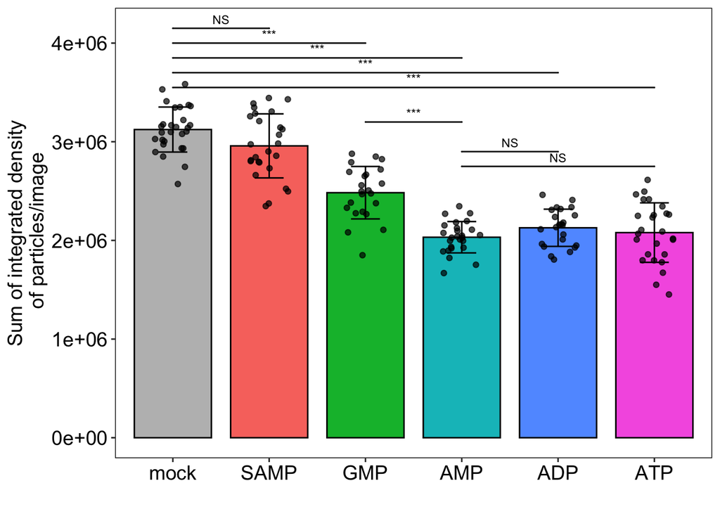

```r
## p値を手動で描くための数値を格納するオブジェクト
  annot1 = c("NS", "***", "***","***","***","***","NS","NS")
  y_position1 = c(4.15e+06,4.0e+06,3.85e+06,3.7e+06,3.55e+06, 3.2e+06,2.9e+06,2.75e+06)
  xmin1 = c(1,1,1,1,1,3,4,4)
  xmax1 = c(2,3,4,5,6,4,5,6)

plot_si <- mean_sd_sum_intden %>% ggplot(aes(x= metabolite, y=mean_sum_intden))+
  geom_bar(aes(fill=metabolite), stat="identity", color="black", # colorは枠線の色
           width = 0.8, position = position_dodge(width = 0.9)) + # widthでバーの幅を、position_dodge(width)でバー間の距離を規定
  geom_signif(xmin = xmin1, xmax = xmax1, y_position = y_position1, annotations = annot1, tip_length = 0.00, textsize =  3) +
  geom_errorbar(limits_sum_intden, width = 0.3, position = position_dodge(width=0.9))+
  scale_fill_manual(values = c('#bdbdbd',"#F8766D", "#00BA38", "#00BFC4", "#619CFF", "#F564E3")) + # fillの色を指定
  geom_jitter(sum_intden, mapping=aes(x=metabolite, y= sum_intden),size = 1.5,
              alpha=0.7, width = 0.2, height = 0)+
  ylab("Sum of integrated density\n of particles/image") +   ## y軸のラベル
  xlab("")+                   ## x軸のラベル
  # ylim(0,3.2e+06)+          ## y軸のレンジ
  theme( axis.title.y = element_text(size=14), axis.text.y = element_text(size=14,color = "black"),
         axis.title.x = element_text(size=14), axis.text.x = element_text(size=14,color = "black")
         ,legend.position = "none" #凡例を消す
         ,panel.border = element_rect(fill = NA, linewidth = 0.5) # パネルを枠で囲む
         ,panel.background = element_blank()) #背景を白にする
plot_si
```

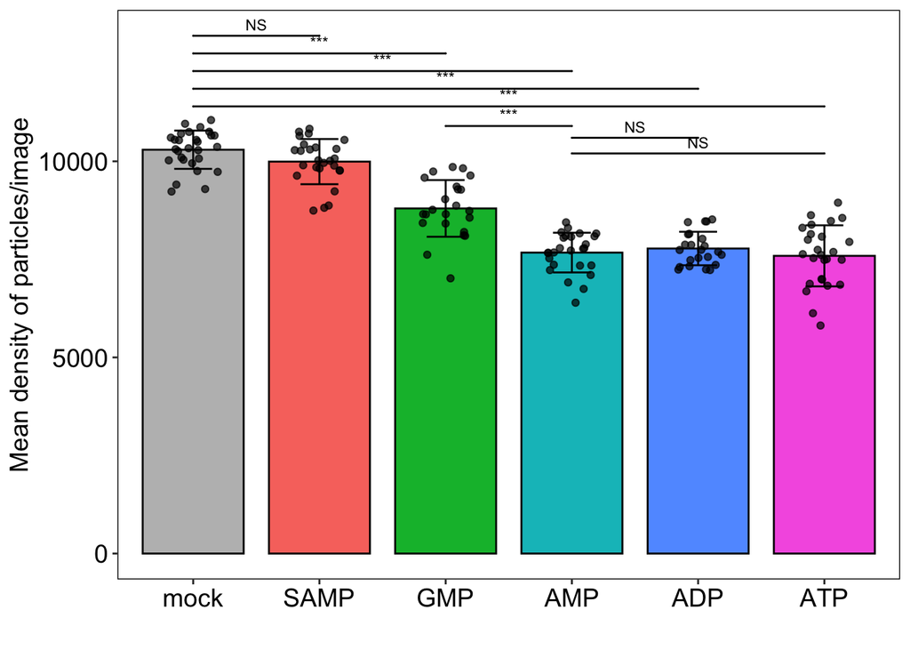

```r
 annot2 = c("NS", "***", "***","***","***","***","NS","NS")
  y_position2 = c(13200,12750,12300,11850,11400,10900,10600,10200)
  xmin2 = c(1,1,1,1,1,3,4,4)
  xmax2 = c(2,3,4,5,6,4,5,6)

plot_mm <- mean_sd_mean_mean %>% ggplot(aes(x= metabolite, y=mean_mean_mean))+
  geom_bar(aes(fill=metabolite),stat="identity", color="black",width = 0.8, position = position_dodge(width = 0.9))+
  geom_signif(xmin = xmin2, xmax = xmax2, y_position = y_position2, annotations = annot2, tip_length = 0.00, textsize =  3) +
  scale_fill_manual(values = c('#bdbdbd',"#F8766D", "#00BA38", "#00BFC4", "#619CFF", "#F564E3"))+
  geom_errorbar(limits_mean_mean, width = 0.3, position = position_dodge(width=0.9))+
  geom_jitter(mean_mean, mapping=aes(x=metabolite, y= mean_mean),size = 1.5,
              alpha=0.7, width = 0.2, height = 0)+
  ylab("Mean density of particles/image") + # y軸のラベル
  xlab("")+   # x軸のラベル
  theme( axis.title.y = element_text(size=14), axis.text.y = element_text(size=14,color = "black"),
         axis.title.x = element_text(size=14), axis.text.x = element_text(size=14,color = "black")
         ,legend.position = "none" #凡例を消す
         ,panel.border = element_rect(fill = NA, linewidth = 0.5)# パネルを枠で囲む
         ,panel.background = element_blank())
plot_mm
```

# 7 グラフに注釈を付ける

`annotate()`を使用してx軸の「SAMP」から「ATP」まで下線を引き、テキスト「500 µM」を追加する。  
`coord_cartesian()`で`clip = "off"`とすることでプロットの外側に注釈を追加できる。

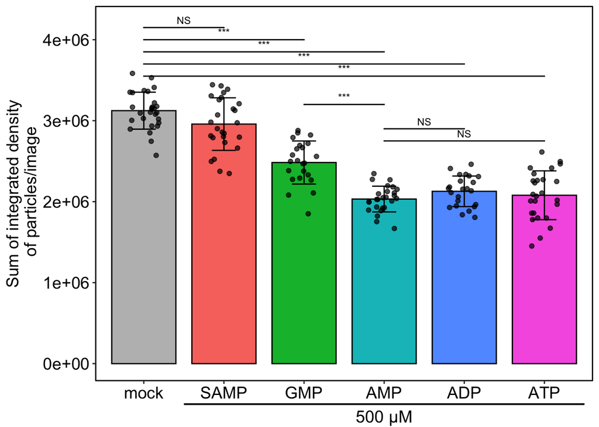

```r
plot_si +
  # annotate()で下線とテキストを追加
  annotate("segment", x = 1.5, xend = 6.5, y = -0.5e+06, yend = -0.5e+06, colour = "black", size = 0.7) +
  annotate("text", x = 4, y = -0.65e+06, label = "500 µM", size = 5)+
  coord_cartesian(ylim = c(0e+00, 4.2e+06), clip = "off")
```

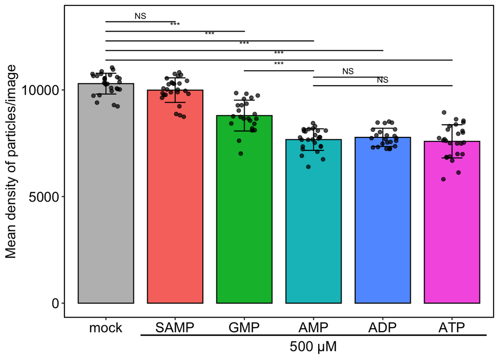

```r
plot_mm +
  annotate("segment", x = 1.5, xend = 6.5, y = -1500, yend = -1500, colour = "black", size = 0.7) +
  annotate("text", x = 4, y = -2000, label = "500 µM", size = 5)+
  coord_cartesian(ylim = c(0, 13300), clip = "off")
```